# LeningClub信贷数据风险分析

## 一、项目介绍

Lending Club 创立于2006年，是全球最大的撮合借款人和投资人的线上金融平台，它利用互联网模式建立了一种比传统银行系统更有效率的、能够在借款人和投资人之间自由配置资本的机制。这种模式就是目前为人熟知的P2P。

P2P即基于互联网平台的网络借贷行为。P2P公司充当中介作用，沟通投资人（资金充裕方）和借款人（资金短缺方），提高资金融通的效率，减少信息不对称，降低了小额借贷的难度。这种模式带来便利的同时无形中亦增加了借款人拖欠借款或欠款不还的风险，因此合理地评估借款人信用等级并进行利率定价就显得尤为重要。

注：数据集是 LendingClub 平台发生借贷的业务数据（2017年第三季度），具体数据集可以从 [LendingClub 官网](https://www.lendingclub.com/info/download-data.action) 下载。

本项目基于python，尝试对Lending Club平台的贷款数据进行分析，以了解该平台的业务特性及利率定价，并根据该平台的经营情况，给出有针对性的建议。

主要对以下问题进行探讨：

- LendingClub 贷款的状态是怎样的，违约的比例有多少？
- 贷款人的风险等级是怎样分布的，高风险等级的客户多不多？
- 人们一般会在 LendingClub 上贷款多大金额？
- LendingClub 的客户主要出于什么目的选择贷款？
- 在 LendingClub 上贷款的利率是多少，什么利率的人数最多？
- LendingClub 是否会给有违约经历的人贷款？
- 不同州的人进行贷款的金额有没有不同？
- 贷款期限、信用评级、贷款用途、贷款金额和与贷款利率有什么关系？哪个变量的影响比较大？

## 二、理解数据

导入相关数据分析及可视化包：

```python
# 导入需要的包
import pandas as pd
import numpy as np

import matplotlib.pyplot as plt
%matplotlib inline  # 将图片内嵌在交互窗口
plt.style.use('ggplot')  # 风格设置近似R这种的ggplot库

import seaborn as sns
sns.set_style('whitegrid')

# pd.set_option('display.max_columns', None)  # 显示df所有列
pd.set_option('display.max_rows', None)  # 显示df所有行

# 忽略弹出的warnings
import warnings
warnings.filterwarnings('ignore')
```

导入 LendingClub 贷款数据：

```python
df = pd.read_csv("LoanStats_2017Q3.csv", skiprows=1, low_memory=False)
```

首先预览基本内容，查看该数据集的相关信息，Pandas为我们提供很多可以方便查看和检查数数据的方法，有 `df.head(n)`、`df.tail(n)`、`df.shape()`、`df.info()`、`df.dtypes` 等 。

```python
# 查看行索引和列名
# print(df.index)
# print(df.columns)

print(df.info())

# 查看数据所包含行数及列数
print(df.shape)
```

```
<class 'pandas.core.frame.DataFrame'>
RangeIndex: 122703 entries, 0 to 122702
Columns: 145 entries, id to settlement_term
dtypes: float64(107), object(38)
memory usage: 135.7+ MB
None
(122703, 145)
```

```python
# 查看前5行
df.head()
```

|  | id | member_id | loan_amnt | funded_amnt | funded_amnt_inv | term | int_rate | installment | grade | sub_grade | ... | hardship_payoff_balance_amount | hardship_last_payment_amount | disbursement_method | debt_settlement_flag | debt_settlement_flag_date | settlement_status | settlement_date | settlement_amount | settlement_percentage | settlement_term |
| --- | --- | --- | --- | --- | --- | --- | --- | --- | --- | --- | --- | --- | --- | --- | --- | --- | --- | --- | --- | --- | --- |
| 0 | NaN | NaN | 32000.0 | 32000.0 | 32000.0 | 36 months | 11.99% | 1062.71 | B | B5 | ... | NaN | NaN | Cash | N | NaN | NaN | NaN | NaN | NaN | NaN |
| 1 | NaN | NaN | 7000.0 | 7000.0 | 7000.0 | 36 months | 7.97% | 219.26 | A | A5 | ... | NaN | NaN | Cash | N | NaN | NaN | NaN | NaN | NaN | NaN |
| 2 | NaN | NaN | 16000.0 | 16000.0 | 16000.0 | 36 months | 7.97% | 501.17 | A | A5 | ... | NaN | NaN | Cash | N | NaN | NaN | NaN | NaN | NaN | NaN |
| 3 | NaN | NaN | 33000.0 | 33000.0 | 33000.0 | 36 months | 7.21% | 1022.12 | A | A3 | ... | NaN | NaN | Cash | N | NaN | NaN | NaN | NaN | NaN | NaN |
| 4 | NaN | NaN | 40000.0 | 40000.0 | 40000.0 | 60 months | 15.05% | 952.65 | C | C4 | ... | NaN | NaN | Cash | N | NaN | NaN | NaN | NaN | NaN | NaN |

5 rows × 145 columns

```python
isd = df['issue_d'].unique()
print(isd)
```

```
['Sep-2017' 'Aug-2017' 'Jul-2017' nan]
```

初步观察得出，这是 LendingClub 平台在2017年7,8,9三个月的信贷数据。这份数据一共 122703 行，145 列。数值类型数据（float）共计 107 列，非数值类型数据（object）共计 38 列。由于数据所涉及列数太多，后文我们考虑根据分析需求选择子集进行分析。

接下来使用了Numpy，Pandas 科学计算包进行数据清洗，使用 Matplotlib 可视化包进行数据可视化。

## 三、清洗数据

在这个阶段，主要的目标是合理地检查并处理数据。

例如：

- 如果数据有唯一的标记符，是否真的只有一个？
- 数据是什么类型，是否合理？
- 每个字段是否对于分析问题有意义？
- 数据应该怎么调整才能适用于接下来的分析和挖掘？
- 数据集是否存在异常值？

常用的数据清洗工作包括：去除无关列、列名重命名、重复数据处理，缺失数据处理、数据类型转换、数据排序、异常值处理。

### 3.1、去除无关列

由于本数据集的列太多，我们初步聚焦11个重要的变量展开分析，特别是我们最为关注的贷款属性变量：

```python
# 根据需求选择子集
used_col = ['loan_amnt', 'term', 'int_rate', 'grade', 'issue_d', 'addr_state',
            'loan_status', 'purpose', 'delinq_2yrs', 'annual_inc', 'emp_length']
df = df[used_col]

# 查看前五行数据
df.head()

# 查看第一行数据
# df.iloc[0]
```

|  | loan_amnt | term | int_rate | grade | issue_d | addr_state | loan_status | purpose | delinq_2yrs | annual_inc | emp_length |
| --- | --- | --- | --- | --- | --- | --- | --- | --- | --- | --- | --- |
| 0 | 32000.0 | 36 months | 11.99% | B | Sep-2017 | NJ | Current | credit_card | 2.0 | 155000.0 | 10+ years |
| 1 | 7000.0 | 36 months | 7.97% | A | Sep-2017 | IL | Current | debt_consolidation | 0.0 | 32000.0 | 10+ years |
| 2 | 16000.0 | 36 months | 7.97% | A | Sep-2017 | VA | Current | debt_consolidation | 0.0 | 79077.0 | 5 years |
| 3 | 33000.0 | 36 months | 7.21% | A | Sep-2017 | TX | Current | debt_consolidation | 0.0 | 107000.0 | < 1 year |
| 4 | 40000.0 | 60 months | 15.05% | C | Sep-2017 | TX | Current | debt_consolidation | 0.0 | 120000.0 | 9 years |

### 3.2、重复值处理

先查看数据集中的重复率：

```python
(df.shape[0] - df.drop_duplicates().shape[0]) / (df.shape[0])
```

```
0.0007579276790298526
```

```python
df = df.drop_duplicates()
print(df.shape)
```

```
(122610, 11)
```

### 3.3、缺失值处理

对于缺失数据，一般有这么几种处理方法：

(0)若某列缺失数据占比很大，则直接删除该列；

(1)若某列缺失数据占比很小，则需要考虑对缺失值进行删除还是填充；

(2)如果是"float64"类型，可以用这一列的平均值填充；

(3)如果是"Object"数据，可以用这一列出现次数最多的值填充，或用"Unknown"填充；

(4)使用模型预测缺失值；

(5)根据业务知识和对指标的理解，自行填充缺失值。

对于数据值型数据缺失问题，主要有两种处理方法，具体选择哪种处理思路要根据数据意义及缺失比例灵活选择：

- 删除：drop方法
- 填充：fillna方法（填充0、均值、中位数、众数、上下数据）

先查看每列数据的缺失率：

```python
# print(df.isnull().any())
df.apply(lambda x: sum(x.isnull()) / len(x))
```

```
loan_amnt      0.000008
term           0.000008
int_rate       0.000008
grade          0.000008
issue_d        0.000008
addr_state     0.000008
loan_status    0.000008
purpose        0.000008
delinq_2yrs    0.000008
annual_inc     0.000008
emp_length     0.070598
dtype: float64
```

可以看出，工作年限emp_length缺失数据较多，但由于样本量比较大，缺失数据比例为 7% 左右。因此直接删除缺失部分。

```python
# 删除含有缺失值的行
df = df.dropna(axis=0, how='any')
print(df.shape)
```

```
(113954, 11)
```

### 3.4、数据类型转换

```python
# 查看各列的数据类型
df.dtypes
```

```
loan_amnt      float64
term            object
int_rate        object
grade           object
issue_d         object
addr_state      object
loan_status     object
purpose         object
delinq_2yrs    float64
annual_inc     float64
emp_length      object
dtype: object
```

此时利率 int_rate 是 object 类型。为了方便后续分析，使用 `astype` 方法将利率 int_rate 转换为数值类型数据。

```python
# 先使用str.replace方法将字符串中的“ % ”去掉，再使用astype
df.int_rate = df.int_rate.str.replace('%',' ').astype('float')

df.dtypes
```

```
loan_amnt      float64
term            object
int_rate       float64
grade           object
issue_d         object
addr_state      object
loan_status     object
purpose         object
delinq_2yrs    float64
annual_inc     float64
emp_length      object
dtype: object
```

```python
# 分类统计数据类型
df.dtypes.value_counts()
```

```
object     7
float64    4
dtype: int64
```

### 3.5、数据排序

```python
# 根据贷款比率从高到低进行排序
df = df.sort_values(by='int_rate', ascending=False)

# 经过上述操作后索引变得不连续，所以使用reset_index重置索引
df = df.reset_index(drop=True)
print(df.shape)
df.tail()
```

```
(113954, 11)
```

|  | loan_amnt | term | int_rate | grade | issue_d | addr_state | loan_status | purpose | delinq_2yrs | annual_inc | emp_length |
| --- | --- | --- | --- | --- | --- | --- | --- | --- | --- | --- | --- |
| 113949 | 10000.0 | 36 months | 5.32 | A | Jul-2017 | CA | Current | debt_consolidation | 0.0 | 70000.0 | 3 years |
| 113950 | 12600.0 | 36 months | 5.32 | A | Jul-2017 | FL | Current | debt_consolidation | 0.0 | 80000.0 | < 1 year |
| 113951 | 10000.0 | 36 months | 5.32 | A | Aug-2017 | NV | Current | home_improvement | 0.0 | 115000.0 | 10+ years |
| 113952 | 15000.0 | 36 months | 5.32 | A | Sep-2017 | TN | Current | home_improvement | 0.0 | 45000.0 | < 1 year |
| 113953 | 17500.0 | 36 months | 5.32 | A | Jul-2017 | NC | Current | debt_consolidation | 0.0 | 48000.0 | < 1 year |

**到这里，数据清洗工作完成，使用describe方法概览数据**

对DataFrame使用describe方法，数值类型的对象将返回一系列描述统计值。

```python
df.describe()
```

|  | loan_amnt | int_rate | delinq_2yrs | annual_inc |
| --- | --- | --- | --- | --- |
| count | 113954.000000 | 113954.000000 | 113954.000000 | 1.139540e+05 |
| mean | 14807.946189 | 13.454196 | 0.361979 | 8.147998e+04 |
| std | 9676.642372 | 5.357649 | 0.975158 | 3.338759e+05 |
| min | 1000.000000 | 5.320000 | 0.000000 | 0.000000e+00 |
| 25% | 7200.000000 | 9.930000 | 0.000000 | 4.800000e+04 |
| 50% | 12000.000000 | 12.620000 | 0.000000 | 6.783950e+04 |
| 75% | 20000.000000 | 16.020000 | 0.000000 | 9.600000e+04 |
| max | 40000.000000 | 30.990000 | 28.000000 | 1.100000e+08 |

将清洗过的数据进行保存：

```python
df.to_csv('clean_loans_2017q3.csv', index=False)
```

## 四、分析数据

### 4.1、单维变量分析

首先进行单维变量分析，对2017年第三季度**贷款状态分布、贷款金额分布、贷款期限分布、贷款用途分布、客户信用等级分布、贷款利率分布、违约次数分布**进行分析，并对结果进行可视化，从而研究 LendingClub 平台贷款的业务特性。

#### 1 ）贷款状态分布

```python
# 查看该列有哪些值
df.loan_status.unique()
```

```
array(['Current', 'Fully Paid', 'In Grace Period', 'Late (31-120 days)',
       'Late (16-30 days)', 'Charged Off'], dtype=object)
```

这些值不是很直观，为了更方便分析，将六种贷款状态进行分类，分为**正常(=0)**和**违约(=1)**，贷款状态分类依据主要参考 [The 10 loan status variants explained](https://help.bitbond.com/article/20-the-10-loan-status-variants-explained)。

贷款状态分为7种：

- Current：正在还款中
- Fully Paid：已还清
- In Grace Period：宽限期
- Late (16-30 days)：逾期16-30天
- Late (31-120 days)：逾期31-120天
- Default：违约
- Charged Off：坏账

```python
loan_status = pd.Series(df["loan_status"], copy=True)
codeDict = {'Current':0,'Fully Paid':0,'In Grace Period':1,'Late (31-120 days)':1,'Late (16-30 days)':1,'Charged Off':1}

for key, value in codeDict.items():
    loan_status.replace(key, value, inplace=True)

df["loan_status_coded"] = loan_status
```

```python
# df.loan_status_coded.value_counts()
pd.value_counts(df["loan_status_coded"])
```

```
0    111899
1      2055
Name: loan_status_coded, dtype: int64
```

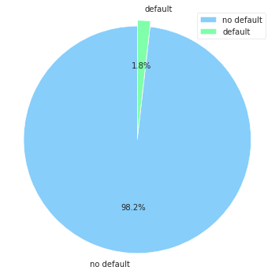

```python
plt.figure(figsize=(6, 6))
label_list = ["no default", "default"]    # 各部分标签
size = [111845, 2055]    # 各部分大小
color = ["#87CEFA", "#7FFFAA"]     # 各部分颜色
explode = [0.05, 0]   # 各部分突出值
"""
绘制饼图
explode：设置各部分突出
label:设置各部分标签
labeldistance:设置标签文本距圆心位置，1.1表示1.1倍半径
autopct：设置圆里面文本
shadow：设置是否有阴影
startangle：起始角度，默认从0开始逆时针转
pctdistance：设置圆内文本距圆心距离
返回值
l_text：圆内部文本，matplotlib.text.Text object
p_text：圆外部文本
"""
patches, l_text, p_text = plt.pie(size, explode=explode, colors=color, labels=label_list, labeldistance=1.1, autopct="%1.1f%%", shadow=False, startangle=90, pctdistance=0.6)
plt.axis("equal")    # 设置横轴和纵轴大小相等，这样饼才是圆的
plt.legend()
plt.show()
```

从图中可以看出，平台贷款发生违约的数量占少数。贷款状态为正常的有111,899个，贷款正常状态占比为98.2%，该平台违约率相对较低。

#### 2 ）贷款金额分布

```python
df.loan_amnt.describe()
```

```
count    113954.000000
mean      14807.946189
std        9676.642372
min        1000.000000
25%        7200.000000
50%       12000.000000
75%       20000.000000
max       40000.000000
Name: loan_amnt, dtype: float64
```

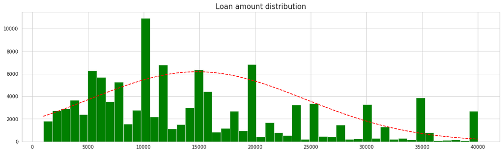

```python
from scipy.stats import norm

plt.figure(figsize=(18, 5))
x = np.linspace(1000, 40000, 50, endpoint=True)
plt.title('Loan amount distribution', fontsize='15')
n, bins, patches = plt.hist(df['loan_amnt'], color='green', bins=x)
plt.tick_params(axis='both', labelsize=10)  # 调整坐标字体大小

mu =np.mean(df['loan_amnt']) #计算均值
sigma =np.std(df['loan_amnt'])

# plt.figure(figsize=(18, 3))
y = norm.pdf(bins, mu, sigma)*0.15e9  # 拟合一条最佳正态分布曲线y
plt.plot(bins, y, 'r--')  # 绘制y的曲线

plt.show()
```

平台贷款呈现右偏正态分布，贷款金额最小值为1,000美元，最大值为40,000美元，中位数为12,000美元，平均数为14807.9美元。

可以看出平台的贷款业务主要以小额贷款为主，这有利于分散风险，手续简单，放贷过程快，贷款范围较广。

#### 3 ）贷款期限分布

```python
df.select_dtypes(include=['object']).describe().T
```

|  | count | unique | top | freq |
| --- | --- | --- | --- | --- |
| term | 113954 | 2 | 36 months | 81370 |
| grade | 113954 | 7 | C | 39117 |
| issue_d | 113954 | 3 | Aug-2017 | 40526 |
| addr_state | 113954 | 49 | CA | 15240 |
| loan_status | 113954 | 6 | Current | 108002 |
| purpose | 113954 | 12 | debt_consolidation | 64490 |
| emp_length | 113954 | 11 | 10+ years | 39113 |

```python
pd.value_counts(df["term"])  # 分类统计贷款期限
```

```
 36 months    81370
 60 months    32584
Name: term, dtype: int64
```

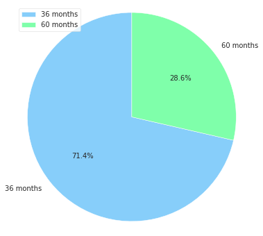

```python
plt.figure(figsize=(6, 6))
label_list = ["36 months", "60 months"]    # 各部分标签
size = [81331, 32569]    # 各部分大小
color = ["#87CEFA", "#7FFFAA"]     # 各部分颜色
explode = [0, 0]   # 各部分突出值

patches, l_text, p_text = plt.pie(size, explode=explode, colors=color, labels=label_list, labeldistance=1.1, autopct="%1.1f%%", shadow=False, startangle=90, pctdistance=0.6)
plt.axis("equal")    # 设置横轴和纵轴大小相等，这样饼才是圆的
plt.legend()
plt.show()
```

Lending Club 平台有两种贷款期限：36 months和60 months，其中以36 months期限的贷款为主，占比为71.4%。一般来说，贷款期限越短，违约风险越低，贷款期限越长，不确定性越大，违约风险更高，由此看出 LendingClub 有意通过控制期限来控制违约风险。

#### 4 ）贷款用途分布

```python
df['purpose'].value_counts() # 按借款用途统作统计
```

```
debt_consolidation    64490
credit_card           22255
home_improvement       8894
other                  8230
major_purchase         2923
medical                1727
car                    1382
small_business         1224
vacation               1104
moving                 1021
house                   634
renewable_energy         70
Name: purpose, dtype: int64
```

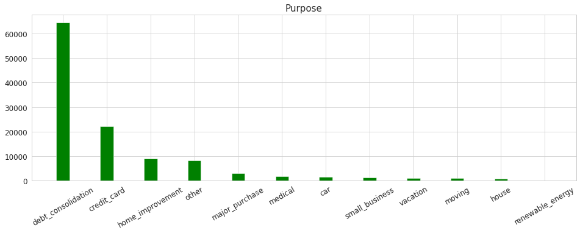

```python
plt.figure(figsize=(16, 5))
bins = list(df['purpose'].value_counts().index)
values = list(df['purpose'].value_counts().values)

plt.title('Purpose', fontsize='15')
plt.xticks(rotation=30)
plt.bar(x=bins, height=values, color='green', width=0.3)
plt.tick_params(axis='both', labelsize=12)  # 调整横坐标字体大小
plt.show()
```

由上图贷款目的的最大频数统计可得，2017年第三季度该平台大部分贷款目的为债务重组（借新债还旧债），其次是信用卡还款，第三是住房改善。

一般来说，贷款用途为债务重组和信用卡还款的客户现金流较为紧张，此类客户是在传统银行渠道无法贷款，才转来P2P平台贷款，这部分客户的偿还贷款能力较弱，发生违约的可能性较高。

#### 5 ）客户信用等级分布

```python
df.grade.value_counts()
```

```
C    39117
B    33517
A    19516
D    13710
E     5062
G     1595
F     1437
Name: grade, dtype: int64
```

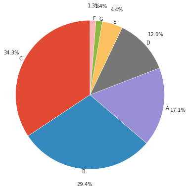

```python
plt.figure(figsize=(6, 6))
label_list = list(df['grade'].value_counts().index)    # 各部分标签
size = list(df['grade'].value_counts().values)    # 各部分大小

patches, l_text, p_text = plt.pie(size, labels=label_list, labeldistance=1.03, autopct="%1.1f%%", shadow=False, startangle=90, pctdistance=1.2)
plt.axis("equal")
plt.show()
```

2017年第三季度C等级的客户最多，绝大多数用户的信用等级为 A~C，三者合计占比为80.8%。此外信用等级为 E~G 类的客户占比仅为7.1%。

#### 6 ）贷款利率分布

```python
df.int_rate.describe()
```

```
count    113954.000000
mean         13.454196
std           5.357649
min           5.320000
25%           9.930000
50%          12.620000
75%          16.020000
max          30.990000
Name: int_rate, dtype: float64
```

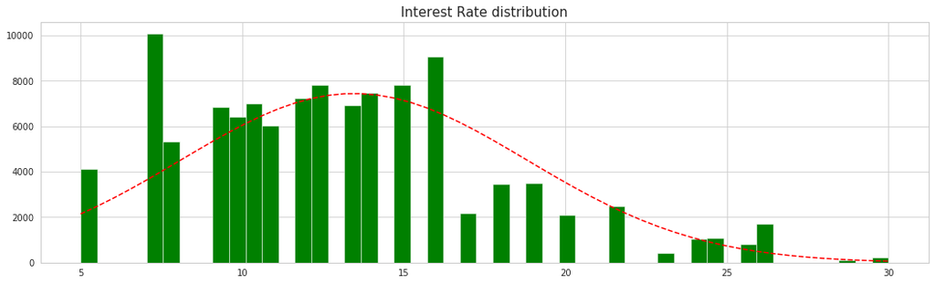

```python
plt.figure(figsize=(18, 5))
x = np.linspace(5, 30, 50, endpoint=True)
plt.title('Interest Rate distribution', fontsize='15')
n, bins, patches = plt.hist(df['int_rate'], color='green', bins=x)
plt.tick_params(axis='both', labelsize=10)  # 调整坐标字体大小

mu =np.mean(df['int_rate']) #计算均值
sigma =np.std(df['int_rate'])

# plt.figure(figsize=(18, 3))
y = norm.pdf(bins, mu, sigma)*1e5  # 拟合一条最佳正态分布曲线y
plt.plot(bins, y, 'r--')  # 绘制y的曲线

plt.show()
```

Lending Club平台贷款利率呈现右偏正态分布，利率最大为30.99%，最小为5.32%，中位数为12.62%，平均值为13.45%，说明P2P的利率还是高于银行利率的。利率是资金的价格，利率越高，借款人借贷成本越高，借款人违约的可能性越高。

#### 7 ）违约次数分布

```python
# # 根据 delinq_2yrs 列进行分组并求平均值
# rate_mean = df.groupby('delinq_2yrs').count().values
# purposes = df.groupby('delinq_2yrs').count().index

df['delinq_2yrs'].value_counts().values
```

```
array([90005, 15451,  4765,  1821,   809,   417,   258,   153,    84,
          58,    33,    28,    26,    10,    10,     9,     7,     2,
           2,     2,     1,     1,     1,     1])
```

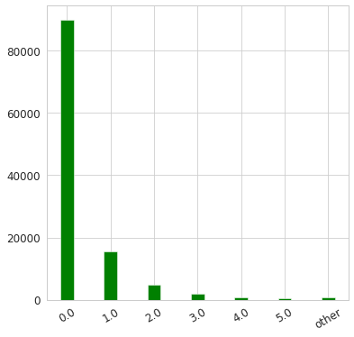

```python
plt.figure(figsize=(6, 6))
labels = list(df['delinq_2yrs'].value_counts().index)
labels = labels[:6] + ['other']
labels = [str(x) for x in labels]
values = list(df['delinq_2yrs'].value_counts().values)
values = values[:6] + [sum(values[6:])]

plt.xticks(rotation=30)
plt.bar(x=labels, height=values, color='green', width=0.3)
plt.tick_params(axis='both', labelsize=12)  # 调整坐标字体大小
plt.show()
```

在贷款客户当中，绝大多数客户都没有过违约经历，说明该平台对客户是否违约非常看重，通过这个指标也可以更好地降低客户违约风险。

### 4.2、多维变量分析

接下来尝试进行多维变量分析，探索变量之间的关系：

- 贷款金额与所属州的关系
- 贷款期限与贷款利率的关系
- 信用评级与贷款利率的关系
- 贷款用途与贷款利率的关系
- 贷款金额与贷款利率的关系
- 违约次数与贷款利率的关系

```python
df_bak = df.copy()
df_bak.head()
```

|  | loan_amnt | term | int_rate | grade | issue_d | addr_state | loan_status | purpose | delinq_2yrs | annual_inc | emp_length | loan_status_coded |
| --- | --- | --- | --- | --- | --- | --- | --- | --- | --- | --- | --- | --- |
| 0 | 20000.0 | 60 months | 30.99 | G | Aug-2017 | CA | Current | debt_consolidation | 0.0 | 50000.0 | 2 years | 0 |
| 1 | 32000.0 | 60 months | 30.99 | G | Jul-2017 | CA | Current | small_business | 2.0 | 155200.0 | 2 years | 0 |
| 2 | 11500.0 | 60 months | 30.99 | G | Sep-2017 | GA | Current | other | 0.0 | 28800.0 | 2 years | 0 |
| 3 | 28000.0 | 60 months | 30.99 | G | Aug-2017 | CA | Current | credit_card | 0.0 | 125000.0 | 3 years | 0 |
| 4 | 28825.0 | 60 months | 30.99 | G | Aug-2017 | GA | Current | debt_consolidation | 1.0 | 80000.0 | 6 years | 0 |

#### 1 ）贷款金额与所属州的关系

```python
data_group_by_state = df.groupby(['addr_state'])['loan_amnt'].sum() # 按州统计贷款金额
data_group_by_state_df= data_group_by_state.reset_index() # 将结果转为 dataframe
data_group_by_state_df.head()
```

|  | addr_state | loan_amnt |
| --- | --- | --- |
| 0 | AK | 3897200.0 |
| 1 | AL | 19563200.0 |
| 2 | AR | 11463775.0 |
| 3 | AZ | 39637375.0 |
| 4 | CA | 230786450.0 |

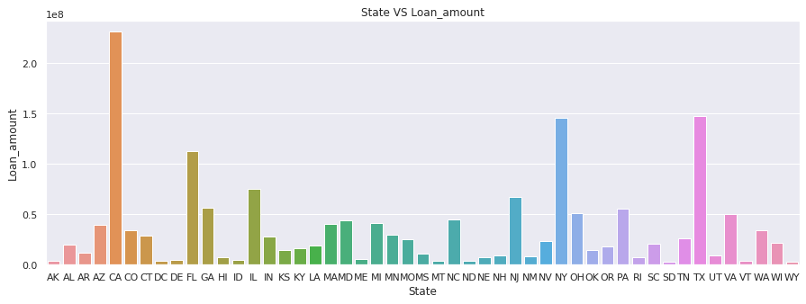

```python
sns.set()
plt.figure(figsize=(15, 5))
sns.set_context("notebook", font_scale=1, rc={"lines.linewidth": 5})
sbarplot = sns.barplot(y='loan_amnt' , x='addr_state' , data=data_group_by_state_df )
plt.xlabel('State')
plt.ylabel('Loan_amount')
plt.xticks(rotation=0)
plt.title('State VS Loan_amount')
sbarplot.figure.savefig("State VS Loan_amount")
```

由上图可知 Lending Club 的总部在加州（CA），因此加州的市场开拓也相对其他较好。其次是德克萨斯州（TX）和纽约州（NY）。

同时，从风险防范角度来看，应重点审核这几个城市贷款申请人的基本信息。

#### 2 ）贷款期限、信用评级与贷款利率的关系

```python
df['grade'].value_counts()  # 查看信用评级的分布
```

```
C    39117
B    33517
A    19516
D    13710
E     5062
G     1595
F     1437
Name: grade, dtype: int64
```

```python
# 使用数据透视表
df.pivot_table(index='grade',columns='term',values='int_rate', aggfunc='mean')
```

| term grade | 36 months | 60 months |
| --- | --- | --- |
| A | 6.990394 | 7.970000 |
| B | 10.586379 | 10.404137 |
| C | 14.199975 | 14.558627 |
| D | 19.052016 | 19.094583 |
| E | 24.726547 | 25.615020 |
| F | 30.186412 | 30.283002 |
| G | 30.895873 | 30.898076 |

对于36个月的贷款类型，信用等级为A的客户的平均贷款利率为6.99%，信用等级为G的客户的平均贷款利率为30.89%。说明资信情况越差，贷款利率越高，60个月的贷款分析同理。

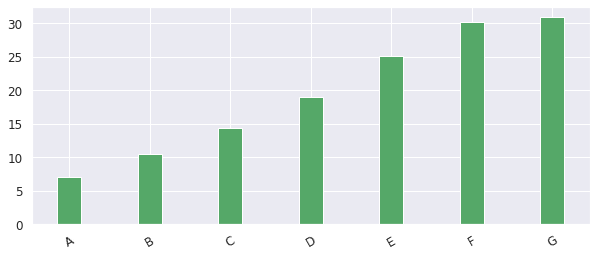

```python
# 根据 grade 列进行分组并求平均值
rate_mean = df.groupby('grade')['int_rate'].mean()

plt.figure(figsize=(10, 4))
labels = list(rate_mean.index)
labels = [str(x) for x in labels]
values = list(rate_mean.values)

plt.xticks(rotation=30)
plt.bar(x=labels, height=values, color='g', width=0.3)
plt.tick_params(axis='both', labelsize=12)  # 调整坐标字体大小
plt.show()
```

从上图可以看出，该平台的利率最高档为30%，而利率最低档为7%左右，总体利率水平也相对传统银行较高。 信用评级从A到G，A的的借款人信用评分最高，财务状况较好，违约发生的可能性较低，因此利率也相对较低。

#### 3 ）贷款用途与贷款利率的关系

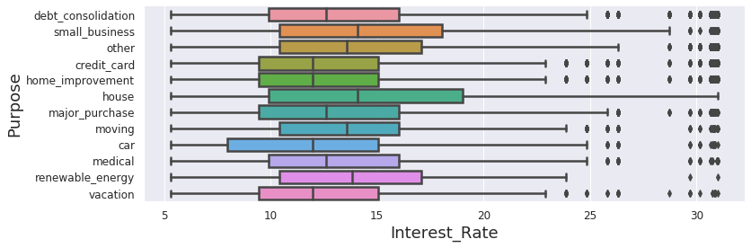

```python
plt.figure(figsize=(12, 4))
sns.set_context("notebook", font_scale=1.5, rc={"lines.linewidth": 2.5})

sboxplot = sns.boxplot(y="purpose", x="int_rate", data=df)
sns.despine(top=True)
plt.tick_params(axis='both', labelsize=12)  # 调整坐标字体大小
plt.xlabel('Interest_Rate')
plt.ylabel('Purpose')
plt.xticks(rotation=0)
plt.show()
```

贷款用途分别为house、small_business以及 renewable energy 的贷款利率较高。其中贷款用途为house的贷款利率为最高。

#### 4 ）贷款金额与贷款利率的关系

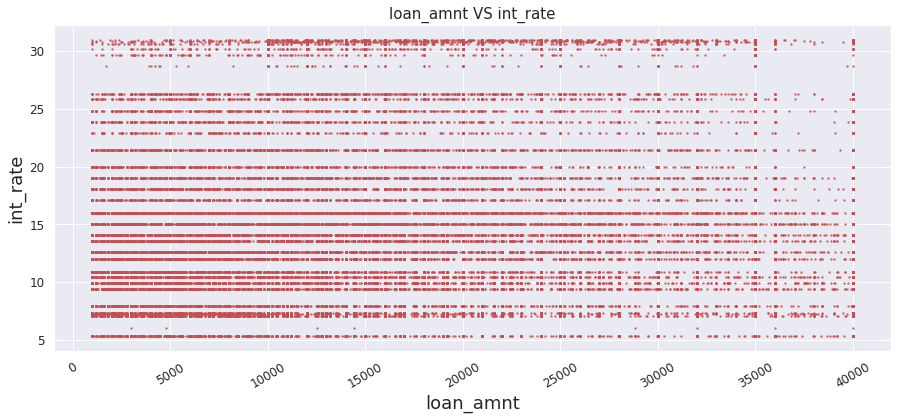

```python
loan_amnt = df['loan_amnt']
int_rate = df['int_rate']

plt.figure(figsize=(15, 6))
plt.xlabel('loan_amnt')
plt.ylabel('int_rate')
plt.xticks(rotation=30)
plt.title('loan_amnt VS int_rate', fontsize='15')
plt.tick_params(axis='both', labelsize=12)  # 调整坐标字体大小
plt.scatter(loan_amnt, int_rate, c='r', s=2, alpha=0.7, );
```

上图是贷款金额和利率的线性关系图，从图中并没有发现贷款金额和贷款利率有明显的关系。

#### 5 ）违约次数与贷款利率的关系

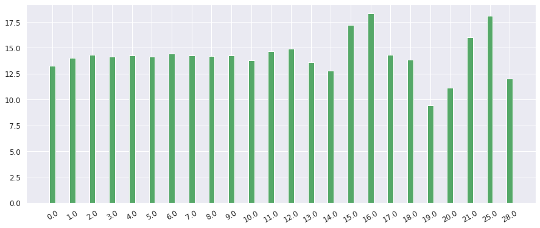

```python
# 根据 delinq_2yrs 列进行分组并求平均值
rate_mean = df.groupby('delinq_2yrs')['int_rate'].mean()

plt.figure(figsize=(15, 6))
labels = list(rate_mean.index)
labels = [str(x) for x in labels]
values = list(rate_mean.values)

plt.xticks(rotation=30)
plt.bar(x=labels, height=values, color='g', width=0.3)
plt.tick_params(axis='both', labelsize=12)  # 调整坐标字体大小
plt.show()
```

## 五、结论与建议

### 5.2、对该平台的建议

1. 贷款业务主要集中在加州、德克萨斯州和纽约州，从风险防范角度来看，应重点审核这几个城市贷款申请人的基本信息。
2. 要限制高利率贷款的人数，利率越高，借款人还款成本越高，违约的可能性越高，平台不能盲目追求高收益。
3. 完善客户画像，根据客户信息确定客户的常见特征，从而确定目标客户群体，完整的客户信息有利于风控人员和系统分析把控违约风险。

### 5.3、本次项目需要改进的地方

1. 违约率虽然比较低，但是可以对违约人的所属州，房屋拥有情况，工作收入，贷款用途等变量进行分析，从而更准确地分辨出可能违约的人，进一步降低违约风险。
2. 增加对贷款人住房情况的分析，因为房屋属于大额资产，贷款人是否持有房子，以及房子是否抵押，对贷款人是否违约的影响还是比较大的。
3. 可以借助机器学习技术对贷款数据进行建模，自动进行风险分析，并得到个变量之间更为准确的关系。